# XGBoosting and AdaBoosting

### Problem Statement :-

- Perform AdaBoost and Extreme Gradient Boosting for the Diabeties dataset

### Data Understanding

```r
library(readr)
db <- read_csv("/Users/thanush/Desktop/Digi 360/Module 20/Datasets-9/Diabetes_RF.csv")
head(db)
```

```
## # A tibble: 6 x 9
##   `Number of time… `Plasma glucose… `Diastolic bloo… `Triceps skin f…
##              <dbl>            <dbl>            <dbl>            <dbl>
## 1                6              148               72               35
## 2                1               85               66               29
## 3                8              183               64                0
## 4                1               89               66               23
## 5                0              137               40               35
## 6                5              116               74                0
## # … with 5 more variables: `2-Hour serum insulin` <dbl>, `Body mass
## #   index` <dbl>, `Diabetes pedigree function` <dbl>, `Age (years)` <dbl>,
## #   `Class variable` <chr>
```

```r
# Renaming the columns
colnames(db) <- c("np","plasma","dbp","tsf_thick", "serum", "BMI", "pedigree", "age", "class")
head(db)
```

```
## # A tibble: 6 x 9
##      np plasma   dbp tsf_thick serum   BMI pedigree   age class
##   <dbl>  <dbl> <dbl>     <dbl> <dbl> <dbl>    <dbl> <dbl> <chr>
## 1     6    148    72        35     0  33.6    0.627    50 YES
## 2     1     85    66        29     0  26.6    0.351    31 NO
## 3     8    183    64         0     0  23.3    0.672    32 YES
## 4     1     89    66        23    94  28.1    0.167    21 NO
## 5     0    137    40        35   168  43.1    2.29     33 YES
## 6     5    116    74         0     0  25.6    0.201    30 NO
```

```r
#converting features into factor
db$class <- as.factor(db$class)
str(db)
```

```
## tibble [768 × 9] (S3: spec_tbl_df/tbl_df/tbl/data.frame)
##  $ np       : num [1:768] 6 1 8 1 0 5 3 10 2 8 ...
##  $ plasma   : num [1:768] 148 85 183 89 137 116 78 115 197 125 ...
##  $ dbp      : num [1:768] 72 66 64 66 40 74 50 0 70 96 ...
##  $ tsf_thick: num [1:768] 35 29 0 23 35 0 32 0 45 0 ...
##  $ serum    : num [1:768] 0 0 0 94 168 0 88 0 543 0 ...
##  $ BMI      : num [1:768] 33.6 26.6 23.3 28.1 43.1 25.6 31 35.3 30.5 0 ...
##  $ pedigree : num [1:768] 0.627 0.351 0.672 0.167 2.288 ...
##  $ age      : num [1:768] 50 31 32 21 33 30 26 29 53 54 ...
##  $ class    : Factor w/ 2 levels "NO","YES": 2 1 2 1 2 1 2 1 2 2 ...
##  - attr(*, "spec")=
##   .. cols(
##   ..   `Number of times pregnant` = col_double(),
##   ..   `Plasma glucose concentration` = col_double(),
##   ..   `Diastolic blood pressure` = col_double(),
##   ..   `Triceps skin fold thickness` = col_double(),
##   ..   `2-Hour serum insulin` = col_double(),
##   ..   `Body mass index` = col_double(),
##   ..   `Diabetes pedigree function` = col_double(),
##   ..   `Age (years)` = col_double(),
##   ..   `Class variable` = col_character()
##   .. )
```

```r
# Checking for missing values
sapply(db, function(x) sum(is.na(x)))
```

```
##        np    plasma       dbp tsf_thick     serum       BMI  pedigree       age
##         0         0         0         0         0         0         0         0
##     class
##         0
```

```r
# Taking only the same number of data points from majority class.
library(caret)
set.seed(1000)
index <- createDataPartition(y = db$class, p = 0.7, list = FALSE)
train <- db[index, ]
test <- db[-index, ]
```

### Extreme Gradient Boosting

To use xgboost package, keep these things in mind: - Convert the categorical variables into numeric using one hot encoding - For classification, if the dependent variable belongs to class factor, convert it to numeric

```r
#convert data frame to data table
library(data.table)
library(mlr)
setDT(train)
setDT(test)
```

```r
train_label <- train$class
test_label <- test$class
```

```r
train_label
```

```
##   [1] YES NO  YES NO  YES NO  YES NO  YES YES NO  NO  YES YES YES NO  YES NO
##  [19] YES YES YES YES NO  NO  NO  YES NO  NO  NO  YES YES NO  YES NO  NO  NO
##  [37] YES NO  NO  NO  YES NO  NO  YES NO  NO  NO  YES NO  NO  YES NO  NO  YES
##  [55] NO  NO  NO  YES NO  NO  NO  NO  NO  NO  NO  YES NO  NO  NO  NO  YES YES
##  [73] NO  NO  NO  NO  NO  NO  YES NO  YES YES YES NO  NO  YES YES NO  YES YES
##  [91] YES YES NO  NO  NO  NO  NO  NO  NO  NO  NO  NO  NO  NO  YES NO  YES YES
## [109] NO  NO  NO  NO  YES YES NO  NO  YES NO  YES NO  NO  YES NO  NO  NO  NO
## [127] YES YES YES YES YES NO  YES NO  YES YES YES NO  NO  NO  NO  NO  YES YES
## [145] YES NO  NO  NO  YES YES YES NO  YES YES YES YES NO  NO  YES NO  YES NO
## [163] NO  YES YES YES NO  NO  YES YES NO  NO  NO  NO  NO  NO  NO  NO  NO  NO
## [181] NO  YES YES NO  NO  NO  NO  NO  NO  NO  NO  YES NO  NO  NO  NO  YES NO
## [199] YES YES YES NO  NO  NO  YES NO  YES NO  YES NO  YES NO  NO  YES YES NO
## [217] NO  YES NO  NO  NO  NO  YES NO  NO  YES NO  NO  NO  NO  YES YES NO  NO
## [235] NO  NO  NO  YES NO  NO  NO  NO  YES YES YES NO  NO  NO  NO  YES NO  YES
## [253] YES NO  NO  YES NO  NO  YES NO  NO  NO  NO  NO  YES YES YES NO  YES NO
```

[output cut: 16 more lines]

```r
new_train <- model.matrix(~.+0,data = train[,-c("class"),with=F])
new_test <- model.matrix(~.+0,data = test[,-c("class"),with=F])
```

```r
train_label <- as.numeric(train_label)-1
test_label <- as.numeric(test_label)-1
```

```r
train_label
```

```
##   [1] 1 0 1 0 1 0 1 0 1 1 0 0 1 1 1 0 1 0 1 1 1 1 0 0 0 1 0 0 0 1 1 0 1 0 0 0 1
##  [38] 0 0 0 1 0 0 1 0 0 0 1 0 0 1 0 0 1 0 0 0 1 0 0 0 0 0 0 0 1 0 0 0 0 1 1 0 0
##  [75] 0 0 0 0 1 0 1 1 1 0 0 1 1 0 1 1 1 1 0 0 0 0 0 0 0 0 0 0 0 0 1 0 1 1 0 0 0
## [112] 0 1 1 0 0 1 0 1 0 0 1 0 0 0 0 1 1 1 1 1 0 1 0 1 1 1 0 0 0 0 0 1 1 1 0 0 0
## [149] 1 1 1 0 1 1 1 1 0 0 1 0 1 0 0 1 1 1 0 0 1 1 0 0 0 0 0 0 0 0 0 0 0 1 1 0 0
## [186] 0 0 0 0 0 0 1 0 0 0 0 1 0 1 1 1 0 0 0 1 0 1 0 1 0 1 0 0 1 1 0 0 1 0 0 0 0
## [223] 1 0 0 1 0 0 0 0 1 1 0 0 0 0 0 1 0 0 0 0 1 1 1 0 0 0 0 1 0 1 1 0 0 1 0 0 1
## [260] 0 0 0 0 0 1 1 1 0 1 0 1 1 0 0 1 0 1 0 0 1 0 0 0 1 1 0 1 0 1 0 0 1 1 0 1 0
## [297] 1 0 0 0 1 0 1 0 0 1 1 0 0 1 0 0 1 0 0 1 0 0 1 0 0 0 0 0 0 1 0 0 0 0 0 0 0
## [334] 0 1 0 0 1 1 0 0 0 0 0 0 0 0 0 0 0 0 1 0 0 1 0 0 1 0 0 0 1 1 0 0 0 0 1 0 0
## [371] 0 0 0 0 0 0 0 0 1 1 1 1 0 0 1 0 0 0 0 0 0 0 0 0 0 0 1 1 0 0 0 0 0 0 0 0 0
## [408] 0 1 0 1 1 0 0 1 1 0 1 1 0 0 1 0 0 1 0 0 0 1 0 1 0 0 1 0 1 0 0 1 0 0 0 0 0
## [445] 0 0 0 0 0 0 1 1 0 0 1 0 1 1 0 0 0 0 1 0 1 0 1 1 1 1 1 1 0 0 0 0 0 1 1 0 0
## [482] 1 0 0 0 0 0 1 1 0 0 0 0 1 0 0 1 1 1 0 0 0 1 0 0 0 0 1 0 0 0 0 0 1 1 1 0 0
## [519] 0 0 0 1 0 0 1 0 0 1 0 0 1 0 1 0 1 0 0 0
```

For xgboost, we’ll use xgb.DMatrix to convert data table into a matrix

```r
library(xgboost)
library(dplyr)
#preparing matrix
dtrain <- xgb.DMatrix(data = new_train,label = train_label)
dtest <- xgb.DMatrix(data = new_test,label=test_label)
```

### Building Model with Default Parameters

```r
#default parameters
params <- list(booster = "gbtree", objective = "binary:logistic", eta=0.3, gamma=0, max_depth=6, min_child_weight=1, subsample=1, colsample_bytree=1)
```

Using the inbuilt xgb.cv function, let’s calculate the best nround for this model.

### Cross Validation

```r
set.seed(1000)
xgbcv <- xgb.cv( params = params, data = dtrain, nrounds = 100, nfold = 5, showsd = T, stratified = T, print_every_n = 10, early_stopping_rounds = 20, maximize = F)
```

[output not shown]

The model returned lowest error at the 2nd (nround) iteration. Also, if you noticed the running messages in your console, you would have understood that train and test error are following each other.

### Training the Model

```r
#first default - model training
xgb1 <- xgb.train (params = params, data = dtrain, nrounds = 2, watchlist = list(val=dtest,train=dtrain), print_every_n = 10, early_stoppin_rounds = 10, maximize = F , eval_metric = "error")
```

[output not shown]

### Model Evolution

```r
#model prediction
xgbpred <- predict (xgb1,dtest)
xgbpred <- ifelse (xgbpred > 0.5,1,0)
```

The objective function binary:logistic returns output probabilities rather than labels. To convert it, we need to manually use a cutoff value. As seen above, I’ve used 0.5 as my cutoff value for predictions. We can calculate our model’s accuracy using confusionMatrix() function from caret package.

```r
#confusion matrix
library(caret)
confusionMatrix(as.factor(xgbpred), as.factor(test_label))
```

```
## Confusion Matrix and Statistics
##
##           Reference
## Prediction   0   1
##          0 127  43
##          1  23  37
##
##                Accuracy : 0.713
##                  95% CI : (0.6499, 0.7706)
##     No Information Rate : 0.6522
##     P-Value [Acc > NIR] : 0.02944
##
##                   Kappa : 0.3283
##
##  Mcnemar's Test P-Value : 0.01935
##
##             Sensitivity : 0.8467
##             Specificity : 0.4625
##          Pos Pred Value : 0.7471
##          Neg Pred Value : 0.6167
##              Prevalence : 0.6522
##          Detection Rate : 0.5522
##    Detection Prevalence : 0.7391
##       Balanced Accuracy : 0.6546
##
##        'Positive' Class : 0
##
```

The accuracy of the model is 71%.

### Feature Importance

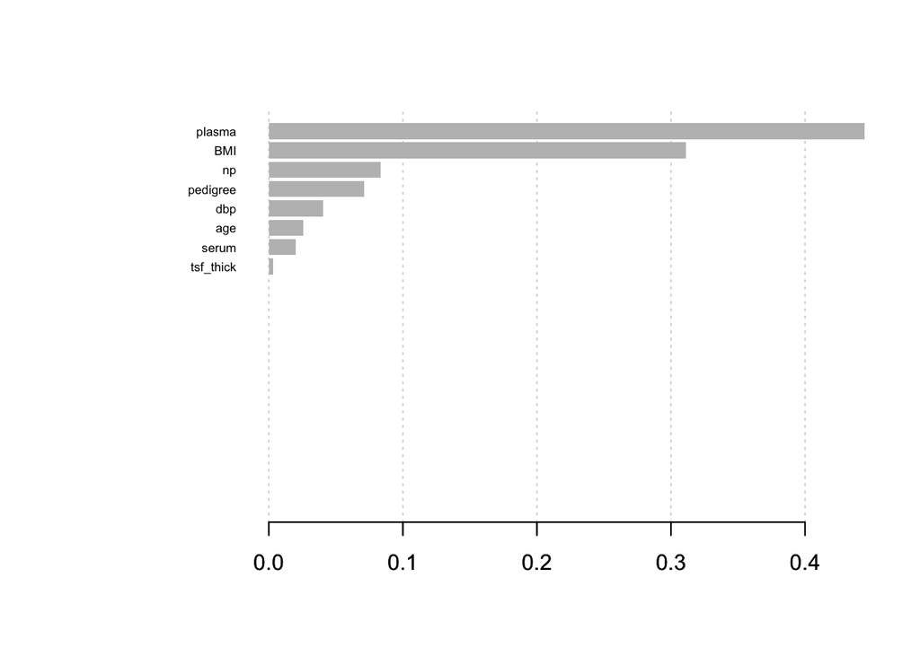

```r
#view variable importance plot
mat <- xgb.importance (feature_names = colnames(new_train),model = xgb1)
xgb.plot.importance (importance_matrix = mat[1:20])
```

The important features are `plasma`, `BMI`,`number of times pregnent`, `pedigree` and `bdp`.

### AdaBoosting Model

```r
# Let's build the model on train data
library(parallel)
library(parallelMap)
library(mlr)
library(dplyr)
library(caret)
library(adabag)
library(rpart)
model = boosting(class~., data=train, boos=TRUE, mfinal=10, coeflearn = 'Zhu',control=rpart.control(maxdepth=3))
```

```r
print(names(model))
```

```
## [1] "formula"    "trees"      "weights"    "votes"      "prob"
## [6] "class"      "importance" "terms"      "call"
```

```r
print(model$trees[1])
```

```
## [[1]]
## n= 538
##
## node), split, n, loss, yval, (yprob)
##       * denotes terminal node
##
##  1) root 538 196 NO (0.6356877 0.3643123)
##    2) plasma< 124.5 313  51 NO (0.8370607 0.1629393) *
##    3) plasma>=124.5 225  80 YES (0.3555556 0.6444444)
##      6) BMI< 30 54  16 NO (0.7037037 0.2962963)
##       12) plasma< 161.5 47  10 NO (0.7872340 0.2127660) *
##       13) plasma>=161.5 7   1 YES (0.1428571 0.8571429) *
##      7) BMI>=30 171  42 YES (0.2456140 0.7543860) *
```

### Model Evolution

```r
pred = predict(model, test)
```

```r
print(pred$confusion)
```

```
##                Observed Class
## Predicted Class  NO YES
##             NO  120  31
##             YES  30  49
```

```r
accuracy = (120 + 49)/(120 + 49 + 31 + 30)
accuracy
```

```
## [1] 0.7347826
```

### Cross Validation Model

```r
set.seed(1000)
cvmodel = boosting.cv(class~., data=train, boos=TRUE, mfinal=10, v=5)
```

```
## i:  1 Sat Jun 20 13:00:23 2020
## i:  2 Sat Jun 20 13:00:26 2020
## i:  3 Sat Jun 20 13:00:30 2020
## i:  4 Sat Jun 20 13:00:33 2020
## i:  5 Sat Jun 20 13:00:37 2020
```

```r
parallelStop()
```

```r
cvmodel
```

```
## $class
##   [1] "YES" "NO"  "NO"  "NO"  "YES" "NO"  "NO"  "NO"  "YES" "NO"  "NO"  "NO"
##  [13] "YES" "NO"  "YES" "NO"  "NO"  "NO"  "YES" "YES" "NO"  "YES" "NO"  "YES"
##  [25] "NO"  "YES" "NO"  "YES" "YES" "NO"  "YES" "NO"  "YES" "NO"  "YES" "NO"
##  [37] "NO"  "NO"  "NO"  "NO"  "YES" "YES" "NO"  "YES" "YES" "YES" "NO"  "NO"
##  [49] "NO"  "NO"  "NO"  "NO"  "YES" "NO"  "YES" "NO"  "NO"  "YES" "NO"  "NO"
##  [61] "NO"  "NO"  "YES" "NO"  "NO"  "NO"  "NO"  "YES" "YES" "NO"  "NO"  "YES"
##  [73] "NO"  "NO"  "NO"  "NO"  "NO"  "NO"  "YES" "NO"  "YES" "YES" "NO"  "NO"
##  [85] "NO"  "NO"  "NO"  "NO"  "NO"  "NO"  "YES" "YES" "NO"  "NO"  "NO"  "NO"
##  [97] "NO"  "NO"  "NO"  "NO"  "NO"  "YES" "YES" "NO"  "YES" "NO"  "YES" "YES"
## [109] "NO"  "NO"  "NO"  "NO"  "YES" "NO"  "NO"  "NO"  "NO"  "NO"  "YES" "NO"
## [121] "YES" "YES" "NO"  "NO"  "NO"  "NO"  "YES" "YES" "NO"  "NO"  "YES" "NO"
## [133] "NO"  "NO"  "NO"  "YES" "NO"  "NO"  "NO"  "NO"  "NO"  "NO"  "YES" "YES"
## [145] "YES" "NO"  "NO"  "YES" "NO"  "YES" "NO"  "YES" "NO"  "NO"  "YES" "YES"
## [157] "NO"  "NO"  "YES" "YES" "YES" "NO"  "NO"  "YES" "YES" "YES" "NO"  "NO"
```

[output cut: 40 more lines]

```r
accuracy = (288 + 112)/(288 + 112 + 76 + 62)
accuracy
```

```
## [1] 0.7434944
```

### Conclusion:-

- With Adaboosting the accuracy is 73%.
- With Adaboosting cross validation the accuracy is 74%
- With XGBoosting the accuracy is 71%.
- The most important features are `plasma`, `BMI`,`number of times pregnent`, `pedigree` and `bdp`.